# Deep Learning — Assignment 13 — Score sheet

Assignment for week 13 of the 2023 Deep Learning course (NWI-IMC070) of the Radboud University.

Please enter your names and group number.**Names:**

**Group:**

## Objectives

In this assignment you will

1. Think about the design of deep neural networks on a higher level
2. Read papers that use deep learning in an application

This week's assignment does not involve any programming.

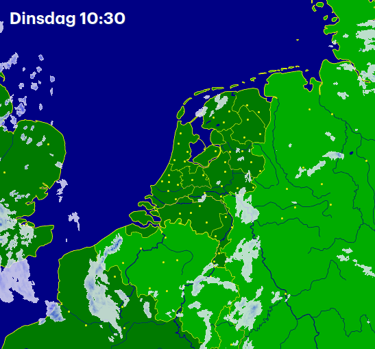

## 13.1 Predicting the weather (7 points)

Most people don't like to be oustide in the rain. Fortunately, we nowadays have radar sensors, that can show the amount of precipitation over a wide area in real time. Weather services like [buienradar](https://buienradar.nl) use this data to forecast when it will rain. But the models they use are often quite simple: just move the rainclouds according to the current wind patterns.

In this assignment you will investigate whether you you can do better with deep learning.

More concretely: The task that we have in mind is to predict the amount of rain up to 3 hours in advance, for the entire country of the Netherlands. The input will be radar images of the amount of rain *currently* falling. For training, there is historical radar data going back several years. You may assume that the data has been gathered with a sample rate of 5 minutes, and at a resolution of 1500m per pixel. See [the KNMI website](https://dataplatform.knmi.nl/dataset/radar-reflectivity-composites-2-0) for more information.

**13.1 a Add comment(a) Are there risks of unfair biases in this task? Explain your answer. (1 point)**

Answer:

No. This task does not involve people, so there is no risk of unfair treatment. Like any model, there can be small biases in the final prediction, but those do not lead to unfair treatment.

*Grading:*

- 1 point for no with a correct explanation.

**13.1 b Add comment(b) Suppose we want to use a deep neural network for this task. How would the input data be represented? (1 point)**

For now, consider using only the current radar data as input.

Answer:

The input data are radar images, indicating the amount of rain. So it makes sense to use a single channel image with real numbers to indicate the amount of rain.

*Grading:*

- 1 point for suggesting an image.
- 0 points for converting the input to RGB.
- It is ok to consider extra input channels that could make sense (see also below).

**13.1 c Add comment(c) What are the targets for prediction? How are they represented? (1 point)**

Answer:

The target is also an image. It could be the radar image from 3 hours into the future.

The simplest representation is the same as the input (one channel, real values). But you could also use binning to make it a multi-class classification problem for each pixel.

*Grading:*

- 1 point for using a future radar image as the target.
- 0.5 point for just saying that the target is an image.

**13.1 d Add comment(d) If we want to make a prediction for the entire country of the Netherlands, how large should the input be to contain all the relevant information? (1 point)**

Answer:

When making a prediction 3 hours in advance, points that are more than 3 hours * wind speed away can not realistically influence that prediction. Wind speed 10 (heavy storm) corresponds to 100km/h, so in that case you need a border of 300km around the country.

Note: The Netherlands is around 300km long north to south, so the height of the input would then need to be cover 900km.

How large this data is as an image depends on the resolution of the radar image. The KNMI data is 1500m per pixel, so then we would have a 600x600 pixel image.

*Grading:*

- 0.5 points for argument that the needed border size depends on the time horizon (and wind speed)
- plus 0.5 points for the right order of magnitude answer (100s-1000 pixels squared)

Rainclouds act differently depending on the terrain. So it can be useful for the model to know which areas of the radar image are above sea, rivers, forests, cities, mountains (as if), etc.

**13.1 e Add comment(e) How can you include this information in the input to the model? (1 point)**

Answer:

This information could be encoded as extra channels in the input. Depending on the type of information, these can be categorical features (type of terrain), or real valued features (elevation, percentage of structures, albedo, etc.)

*Grading:*

- 1 point for the correct answer.

**13.1 f Add comment(f) If information on the type of terrain is not available, could it be learned instead? If so, how? (1 point)**

Answer:

Yes. You could add a fixed (over time) per pixel embedding of the location. This embedding can be learned with backpropagation.

*Grading:*

- 1 point for explaning how to learn this.

The weather also depends on the time of day, in particular on whether the sun is shining. And on the time of year, especially the temperature.

**13.1 g Add comment(g) How could the time of day and time of year be given as inputs to the network? (1 point)**

Answer:

There are several possibilities:

- These could again be encoded in extra channels, with the same value for all pixels.
- An alternative is to add the features in a linear layer, but that doesn't work for a fully convolutional architecture. In a U-net there could be a flattening in the deepest layer, and the features could be concatenated there.
- For a transformer architecture there could be an extra token with the time information. But this makes the architecture more complicated.

Again, these features could be encoded with one hot encoding, or as real numbers.

*Grading:*

- 1 point for adding the features as extra channels.
- 0.5 point for adding the featurse in a linear layer, if it is not clear which layer is used or if the model proposed in 13.2a does not have linear layers.

## 13.2 Weather prediction models (4 points)

Consider a model that uses only the current radar data and terrain as input, to predict rain 3 hours in the future.

**13.2 a Add comment(a) What kind of model would you use for this task? (1 point)**

Answer:

Because the input and output are both images, some kind of U-net makes the most sense here.

We are ignoring the temporal aspect here, so a RNN is not appropriate.

*Grading:*

- 1 point for unet (either with convolutional or with transformer layers)
- 0.5 points for a CNN or vision transformer
- 0 points for another architecture.

**13.2 b Add comment(b) How would the performance of a model that takes only a single radar image as input compare against the simple baseline model that moves the radar image in the wind direction? (1 point)**

Answer:

From a single image it is impossible to tell in what direction the rainclouds are moving. So the predictions will likely be worse than the naive model.

*Grading:*

- 1 point for a good argument

To improve the model, it makes sense to take the temporal aspect into account, by including historical data. So radar scans from 5 minutes ago, 10 minutes ago, etc.

**13.2 c Add comment(c) Give two ways to include this additional data into the model. (2 points)**

Answer:

- You could include the other scans as extra channels in the input to a CNN model.
- You could use a RNN model (like an LSTM or GRU) to handle time. This should still be combined with a CNN, for example by using convolutional layers instead of fully connected layers in an LSTM.
- You could combine the images from different times as patches into a vision transformer. You then need to be careful with how to handle position and time embedding.

*Grading:*

- 1 point per correct suggestion.
- 0.5 points for brief answers ("LSTM", "RNN", "use a transformer" etc.)
- The two suggestions should be different ("LSTM" and "GRU" both fall under "RNN")
- For other suggestions, ask on discord.

## 13.3 MetNet (4 points)

We are not the first people to think about this problem. The paper [MetNet: A Neural Weather Model for Precipitation Forecasting](https://arxiv.org/abs/2003.12140) has tried to tackle the task of predicting rain from radar images.

**13.3 a Add comment(a) Have a look at the MetNet paper and compare their method to your answers in 13.1 and 13.2. What are they doing the same, what are they doing differently? (3 points)**

Answer:

Input encoding:

- The input encoding is similar to what is described above. But the paper includes extra features, in particular visual features from satalite imaging.
- MetNet downsamples the input to 256x256 pixels.

Output encoding:

- The paper suggests making this into a classification problem, by using bins for the amount of rain, instead of doing regression (figure 2).

Model:

- MetNet uses an CNN-LSTM, which is also what we proposed.
- MetNet has a "Spatial Aggregator" module, which we did not consider.
- The model is trained for many different prediction times at the same time. The target time is given as input.

*Grading:*

- 1 point for each of the aspects.
- Where there are differences, the answer should discuss at least one.

**13.3 b Add comment(b) Can the trained MetNet be used in the Netherlands using data from KNMI, without retraining? How? Or why not? (1 point)**

*Grading:*

- 1 point for yes with adaptations
- 0.5 points for not describing needed adaptations
- 0 points for "no"

## 13.4 MetNet - version 2 and 3 (4 points)

You may have noticed that the MetNet paper came out 3 year ago (you can tell the year from the `/YYMM.NNNNN` arxiv url). After that two new models have been released by the same group:

- [MetNet-2: Skillful Twelve Hour Precipitation Forecasts using Large Context Neural Networks](https://arxiv.org/pdf/2111.07470.pdf)
- [MetNet-3: Deep Learning for Day Forecasts from Sparse Observations](https://arxiv.org/pdf/2306.06079.pdf)

**13.4 a Add comment(a) What method is used by MetNet-2 to get a larger receptive field in the convolutions? (1 point)**

Answer:

MetNet-2 uses dilation in the convolution layers, with exponentially increasing dilation factors.

*Grading:*

- 1 point for the right answer.

**13.4 b Add comment(b) How many parameters do the original MetNet and MetNet-3 have? Is one model significantly larger than the other? (1 point)**

Answer:

For MetNet-1: "MetNet has 225M parameters"

For MetNet-3: "The whole network has 227M trainable parameters."

So this is very similar.

*Grading:*

- 1 point for the right answer.

**13.4 c Add comment(c) Estimate how much CO₂ was emitted for training MetNet-3. (2 points)**

Hint: You can find [information on the power consumption of google TPUs here](https://cloud.google.com/tpu/docs/system-architecture-tpu-vm) (the reported numbers are per chip, not per pod).

Hint 2: Make a reasonable assumption for the CO₂ / kwH (see lectures, or [here](https://www.eea.europa.eu/data-and-maps/daviz/co2-emission-intensity-14#tab-chart_7))

Answer:

From the paper: "The network is trained on 512 TPUv3 cores... The fully trained MetNet-3 model took 7 days to train."

From the google cloud documentation, a TPUv3 core uses max 262W, so 512 cores use 134kW, over 7 days this gives 22535kWh.

Assuming emissions of 250 g CO₂e/kwH, we get 5000 kg of CO₂e. About half the yearly energy usage of a Dutch citizen. (CBS reports 11 tons per capita)

*Grading:*

- 2 points for an answer in the right order of magnitude (1-10 tons)

## The end

Well done! Please double check the instructions at the top before you submit your results.

*This assignment has 19 points.* Version 6262555 / 2023-12-11

## Score form

Download the scores as a text file